# Leptospirosis in Kazakhstan: Exercise in R

Otar Chokoshvili

29 July, 2024

# 1 Install and load packages in R.

## 1.1 To conduct this excercise in R you need to install the following packages:

- “tidyverse”
- “knitr”,
- “readxl”,
- “lubridate”,
- “gtsummary”,
- “flextable”

### 1.1.1 Install the required packages, general reccomendations

Packages are installed only once in R, but you need to loed them every time you start new session in R.

**To install package using RStudio you need to use following menu.**

### 1.1.2 Use this code to install and load the required packages simultaneously

```r
knitr::opts_chunk$set(comment=NA, prompt=TRUE, out.width=1050, fig.height=8, fig.width=8)
## istall and load packages that needed
ipak <- function(pkg){
  new.pkg <- pkg[!(pkg %in% installed.packages()[, "Package"])]
  if (length(new.pkg))
    install.packages(new.pkg, dependencies = TRUE)
  sapply(pkg, require, character.only = TRUE)
}
# indicaete package names
packages <- c("tidyverse", "dplyr","readxl","lubridate","gtsummary",  "knitr", "Rcmdr", "flextable", "cardx")

# use created function ipak and pass packages you wont to install and load
ipak(packages)
```

```
## tidyverse     dplyr    readxl lubridate gtsummary     knitr     Rcmdr flextable
##      TRUE      TRUE      TRUE      TRUE      TRUE      TRUE      TRUE      TRUE
##     cardx
##      TRUE
```

# 2 Introduction

## 2.1 Learning Objectives

After completing this exercise, the student should be able to:

- List the components of descriptive epidemiology.
- Given data from a surveillance system or field investigation, use descriptive statistics, tables. graphs, and maps to summarize the descriptive epidemiology.
- Apply computer programs (R and its libraries, including R Commander) to compile the raw data into summary tables, graphs.
- Identify and interpret patterns in the summary statistics, tables and graphs.
- Compile descriptive epidemiologic findings into a working hypothesis.
- Develop a One Health approach for further investigation of this outbreak.

## 2.2 Leptospirosis as a disease

Leptospirosis is a zoonotic disease with epidemic potential, especially after a heavy rainfall, caused by a bacterium called Leptospira. Leptospirosis is caused by any of 10 pathogenic spirochete species of the genus Leptospira. Clinical leptospirosis disease in humans features high fever, severe headache, chills, and muscle aches. Less frequent features may include jaundice (yellow skin and eyes), red eyes, abdominal pain, diarrhea, or a rash. In some cases, infections may occur without symptoms. The diagnosis should be confirmed with laboratory testing of blood or urine. Two reliable serologic tests are available to diagnose Leptospirosis: 1) the microagglutination test (MAT) and 2) the IgM ELISA tests. These become positive 1 to 2 weeks after onset of symptoms. Early diagnosis can be made using darkfield microscopy of fresh blood to visualize the active leptospiral spirochetes, but this requires a well-practiced microscopist. Culture requires specialized media and needs 3 months to complete. For details of other confirmatory tests see the accompanying reference.

Leptospirosis is a zoonosis affecting over 160 mammalian species. Leptospires have been found in domestic livestock (cattle, pigs, horses, sheep, goats, and dogs), pests (rats, mice, and other rodents), and many wild mammals. Leptospira species have many serovars which are adapted to specific non-human mammals. Mammals infected with an adapted strain maintain the infection for months or years without disease while excreting leptospires in their urine. Hence, these mammals are considered to be maintenance or reservoir hosts. Humans are exclusively accidental hosts. Excretion from the urine usually ceases within two weeks after the acute disease ends. The infection is not spread from person-to-person except in a few rare incidents.

Humans become infected through direct contact with infected mammals or through water, food, or soil (usually muddy or wet) containing urine from infected mammals. Exposure may happen from swallowing contaminated water or food or through contact of broken skin or mucosal surfaces with water or soil. Outbreaks and seasonal increases typically follow heavy rains that wash contaminated soil or water into streams, ponds, and other collections of surface water. Pathogenic leptospires do not multiply in water but can survive for months in aquatic environments. The incubation period between a person’s exposure to a contaminated source and becoming sick is usually from 5 to 14 days (average 9-10 days). Rarely, the onset of infection may occur from 2 days to 4 weeks after exposure.

## 2.3 Outbreak of Leptospirosis in Kenkolat village in East Kazakhstan

An outbreak of suspected leptospirosis occurred in Kenkolat village in East Kazakhstan, during August 2004. Kenkolat had a population of 319 people living in approximately 70 houses. Villagers raised livestock, particularly cattle (bovines). Kenkolat lay alongside a permanent stream in hilly steppe land. The climate classification is Dfb (Humid continental, no dry season, with warm summers). Monthly rainfall for the area averages 52 mm in July, 30 mm in August and 540 mm annually. The mean daily temperature is 25$^\circ$C in July and 23$^\circ$C in August.

An epidemiologic team travelled to Kenkolat from August 23 to 27, 2004. The outbreak investigation team collected clinical and epidemiological data from leptospirosis cases reported from the local public health authorities.

**Question 1.** List the variables you will require to measure the values of descriptive epidemiology of this outbreak?

**Answer 1.** Descriptive epidemiology should include information on the disease (clinical features), time, place, and person. Variables to assess might include:

Table 1. List of variables for Leptospirosis outbreak.

| Disease | Time | Place | Person |
| --- | --- | --- | --- |
| Fever | Onset | Home | Age |
| Headache | Hospitalization | Workplace or school | Sex |
| Chills | Death | Possible sources | Occupation |
| Muscle aches | Possible causative factors |  | Contact with mammals |
| Vomiting | Possible controlling factors |  |  |
| Diarrhea |  |  |  |
| Jaundice |  |  |  |
| Red eyes |  |  |  |
| Rash |  |  |  |
| Lab tests including confirmation |  |  |  |

# 3 Data management steps.

## 3.1 Import data into R.

**Using Rcmdr point-and-click:**

Data -> Import data -> From text file…

[figure not shown]

And the dialog box opens.

In the dialogue window that opens:

[figure not shown]

**Import data using R code.**

```r
> ## Import data from excel file.
> df <- read_xlsx("data/LeptospDBclean.xlsx",  sheet = "LeptoDB", na = "NA")
```

### 3.1.1 Check the names of variables in the data set.

**Using Rcmdr point-and-click:**

Data -> Active data sets -> Variables in active data set

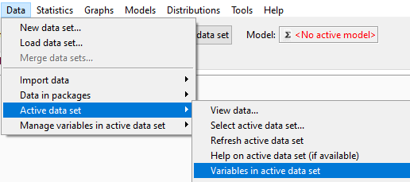

**Using R code :**

```r
> ## Check names of variables in the data set
> names(df)
```

```
 [1] "id"                    "status"                "sex"
 [4] "dob"                   "address"               "occupation"
 [7] "profsn"                "drinkwaterspring"      "drinkwaterwell"
[10] "homeusedwaterspring"   "homeusedwaterwell"     "homeusedwaterriver"
[13] "swiminwaterpond"       "swiminwatertype"       "swimdate"
[16] "ownedgoat"             "owndesheep"            "ownedcow"
[19] "ownedhoarse"           "owneddog"              "ownedcat"
[22] "ownedpig"              "contactgoataug6"       "contactsheepaug6"
[25] "contactcowaug6"        "contacthoarseaug6"     "contactdogaug6"
[28] "contactcataug6"        "contactpigaug6"        "wildanimaonctactaug6"
[31] "fishingaug6"           "fishingaug6place"      "ratinyard"
[34] "ratinhome"             "contactwithillpersons" "dateofsymptoms"
[37] "dateofhospitalization" "datediagnosis"         "outcome"
[40] "headache"              "fever"                 "chils"
[43] "myalgia"               "myalgiaw"              "calfmusc"
[46] "eyered"                "lappet"                "mregdt"
[49] "liveren"               "livrtnd"               "mcpbldlp"
```

### 3.1.2 Delete variables form data set.

**Using Rcmdr point-and-click:**

Data -> Manage variables in active data set -> Delete variables in active data set

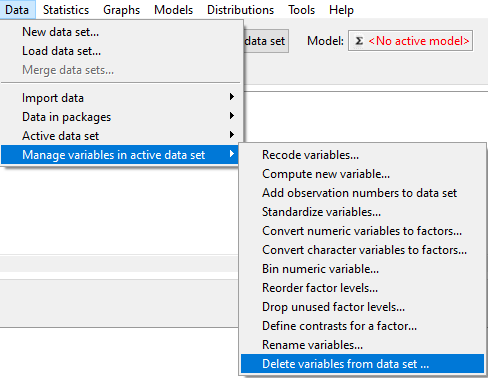

- Then you need to select variable names in the window to delete.

[figure not shown]

- Click Ok.
- Your selected variables are deleted.

**Using R code:**

```r
> ## Delete variables
> df <- df %>%
+   select(-c(calfmusc, eyered, lappet, mregdt, liveren, livrtnd, mcpbldlp))
```

### 3.1.3 View the summary of your data set.

**Using Rcmdr point-and-click:**

Statistics -> Summaries -> Active data set.

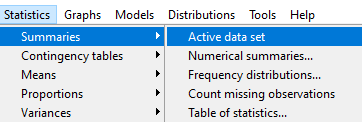

**Using R code:**

```r
> ##  see the summary statistics of data set.
> summary(df)
```

```
       id            status              sex
 Min.   :  1.00   Length:150         Length:150
 1st Qu.: 38.25   Class :character   Class :character
 Median : 75.50   Mode  :character   Mode  :character
 Mean   : 75.66
 3rd Qu.:112.75
 Max.   :151.00

      dob                        address           occupation
 Min.   :1920-01-01 00:00:00   Length:150         Length:150
 1st Qu.:1957-02-19 12:00:00   Class :character   Class :character
 Median :1976-09-19 00:00:00   Mode  :character   Mode  :character
 Mean   :1971-09-19 20:19:12
 3rd Qu.:1986-08-07 18:00:00
 Max.   :2001-08-16 00:00:00

    profsn          drinkwaterspring   drinkwaterwell     homeusedwaterspring
 Length:150         Length:150         Length:150         Length:150
 Class :character   Class :character   Class :character   Class :character
 Mode  :character   Mode  :character   Mode  :character   Mode  :character




 homeusedwaterwell  homeusedwaterriver swiminwaterpond    swiminwatertype
 Length:150         Length:150         Length:150         Length:150
 Class :character   Class :character   Class :character   Class :character
 Mode  :character   Mode  :character   Mode  :character   Mode  :character




    swimdate                     ownedgoat        owndesheep
 Min.   :2004-07-15 00:00:00   Min.   :0.0000   Min.   :0.0000
 1st Qu.:2004-07-20 00:00:00   1st Qu.:1.0000   1st Qu.:1.0000
 Median :2004-07-25 00:00:00   Median :1.0000   Median :1.0000
 Mean   :2004-07-24 08:00:00   Mean   :0.8367   Mean   :0.8639
 3rd Qu.:2004-07-29 00:00:00   3rd Qu.:1.0000   3rd Qu.:1.0000
 Max.   :2004-08-02 00:00:00   Max.   :1.0000   Max.   :1.0000
 NA's   :147                   NA's   :3        NA's   :3
```

[output cut: 45 more lines]

```
 3rd Qu.:2004-08-12 00:00:00.00   3rd Qu.:2004-08-19 00:00:00   3rd Qu.:1.000
 Max.   :2004-08-17 00:00:00.00   Max.   :2004-08-24 00:00:00   Max.   :3.000
 NA's   :121                      NA's   :123                   NA's   :121
    headache         fever           chils        myalgia
 Min.   :1.000   Min.   :37.30   Min.   :1     Min.   :0.0000
 1st Qu.:1.000   1st Qu.:38.00   1st Qu.:1     1st Qu.:1.0000
 Median :1.000   Median :38.70   Median :1     Median :1.0000
 Mean   :1.586   Mean   :38.62   Mean   :1     Mean   :0.7586
 3rd Qu.:2.000   3rd Qu.:39.20   3rd Qu.:1     3rd Qu.:1.0000
 Max.   :4.000   Max.   :40.20   Max.   :1     Max.   :1.0000
 NA's   :121     NA's   :121     NA's   :121   NA's   :121
   myalgiaw
 Length:150
 Class :character
 Mode  :character
```

### 3.1.4 Rename the data set and sort it by id.

**Using Rcmdr point-and-click:**

[figure not shown]

[figure not shown]

**Using R code:**

```r
> ## Rename the data set and sort it by id.
>
> leptodbfinal <- df[order(df$id),]
```

### 3.1.5 Count missing observations fro all variables in data set.

**Using Rcmdr point-and-click:**

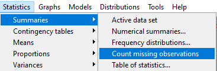

**Using R code:**

```r
> # check numver of missing values in for each variables.
> colSums(is.na(leptodbfinal))
```

```
                   id                status                   sex
                    0                     0                     0
                  dob               address            occupation
                    0                     0                     0
               profsn      drinkwaterspring        drinkwaterwell
                  149                     3                     3
  homeusedwaterspring     homeusedwaterwell    homeusedwaterriver
                    3                     3                     3
      swiminwaterpond       swiminwatertype              swimdate
                    3                    93                   147
            ownedgoat            owndesheep              ownedcow
                    3                     3                     3
          ownedhoarse              owneddog              ownedcat
                    3                     3                     3
             ownedpig       contactgoataug6      contactsheepaug6
                    3                     3                     3
       contactcowaug6     contacthoarseaug6        contactdogaug6
                    3                     3                     3
       contactcataug6        contactpigaug6  wildanimaonctactaug6
                    3                     3                     3
          fishingaug6      fishingaug6place             ratinyard
                    3                   137                     3
            ratinhome contactwithillpersons        dateofsymptoms
                    3                     3                   121
dateofhospitalization         datediagnosis               outcome
                  121                   123                   121
             headache                 fever                 chils
                  121                   121                   121
              myalgia              myalgiaw
                  121                   145
```

### 3.1.6 Recode variables with missing values (NA) to 0:

**Using Rcmdr point-and-click:**

Data -> Manage variables in active data set -> Recode variables

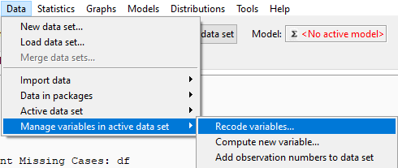

- in the recode variables window select variables you wont to recede and in the code write **`NA=0`**

[figure not shown]

**Using R code:**

```r
> ## replace all NA values to 0 for sleected variables
> leptodbfinal <- leptodbfinal %>%
+   #mutate_if(is.numeric, ~replace_na(., 0))
+   mutate_at(c("contactwithillpersons", "contactsheepaug6", "contactpigaug6", "contacthoarseaug6",
+               "contactgoataug6", "contactdogaug6", "contactcowaug6", "contactcataug6"),  ~replace_na(., 0))
```

### 3.1.7 Recode variables from numeric to factor:

**Using Rcmdr point-and-click:**

Data -> Manage variables in active data set -> Convert numeric variables to factors

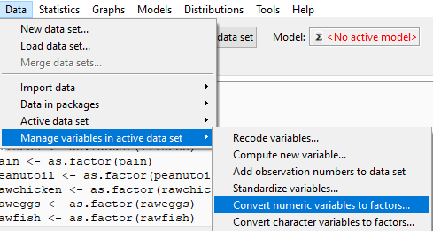

[figure not shown]

**Using R code:**

```r
> leptodbfinal <- leptodbfinal %>%
+   mutate_if(is.numeric, as.factor)
```

### 3.1.8 Convert variable to date

This is the case for variables “dateonset”, “datediagnosis”

**Using Rcmdr point-and-click:**

Data -> Manage variables in active data set -> Compute new variable

-When you click it the new dialogue window pops up

-Type the new variable name: `new_datediagnosis`

-In expression to compute type: `as.Date(datediagnosis)`

-Click OK

You have now created a new date type variable called `new_datediagnosis`

You can repeat this same step to create the date variable “new_dateonset” from variable “dateofsymptoms”

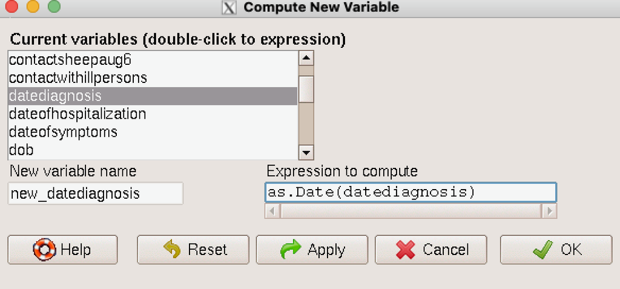

**Using R code:**

```r
> ## Recode dates using dplyr package
> leptodbfinal <- leptodbfinal %>%
+   mutate(new_datediagnosis = as.Date(datediagnosis),
+          new_dateonset = as.Date(dateofsymptoms))
```

### 3.1.9 Calculate difference between two dates

**Using Rcmdr point-and-click:**

- Calculate difference between date of diagnosis and date of onset to detect the delay between diagnosis and onset of disease.

Data -> Manage variables in active data set -> Compute new variable

- In the new variable calcuation window we need to write formula to calculate difference:
- `new_datediff <- as.numeric(new_datediagnosis - new_dateonset)`

[figure not shown]

**Using R code:**

```r
> # calcualate differnce between date of onset and date of diagnosis
> leptodbfinal$new_datediff <- as.numeric(leptodbfinal$new_datediagnosis - leptodbfinal$new_dateonset)
```

### 3.1.10 Create new categorical variable from numeric variable by recoding it.

#### 3.1.10.1 First calculate year of birth from date of birth variable.

**Using Rcmdr point-and-click:**

Data -> Manage variables in active data set -> Compute new variable

- In the new window calculate variable `birth_year`

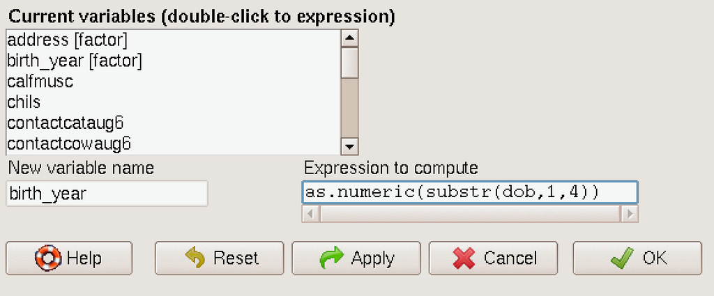

#### 3.1.10.2 Calculate age from year of diagnosis **`2004`** and year of birth.

Data -> Manage variables in active data set -> Compute new variable

- In the new window calculate variable `age`

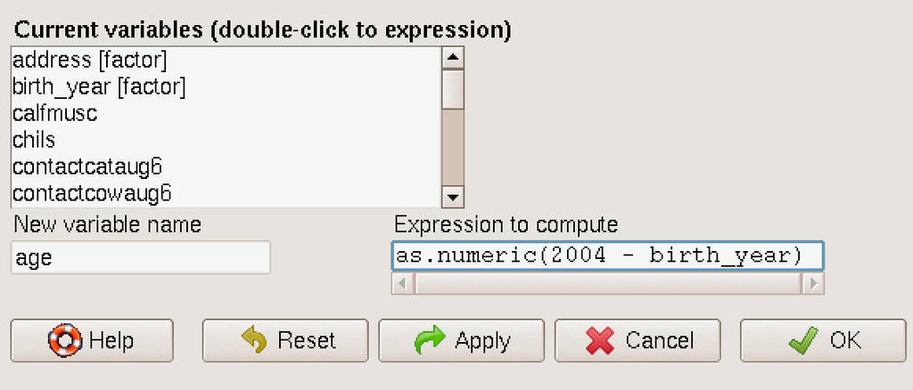

#### 3.1.10.3 Calcualte age groups by recoding age into age group catgories.

Data -> Manage variables in active data set -> Recode variables

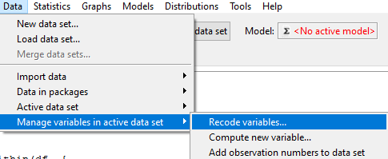

[figure not shown]

**Using R code:**

```r
> ## Substract year from date of birth
> leptodbfinal$birth_year <- as.numeric(substr(leptodbfinal$dob,1,4))
>
> ## Calculate age from 2004 using birth_year
> leptodbfinal$age <- as.numeric(2004 - leptodbfinal$birth_year)
>
> ## Calculate new_age as age groups
> leptodbfinal$age_group <- cut(leptodbfinal$age, breaks = c(0,14,39,100), labels = c("<15", "10-39",  "40+"))
>
> ## Calcualte year of birth, age and age groups using dplyr package in one code.
> leptodbfinal <- leptodbfinal %>%
+ # calculate age variabel from date of birth variable (DOB)
+     mutate(age = as.numeric(2004 - year(dob)),
+   age_group = cut(age, breaks = c(0,14,39,100), labels = c("<15", "10-39",  "40+")))
```

## 3.2 Refresh active data set

In Rcmdr after you create new variables you need to refresh.

**Using Rcmdr point-and-click:**

Data -> Active data set -> Refresh active data set

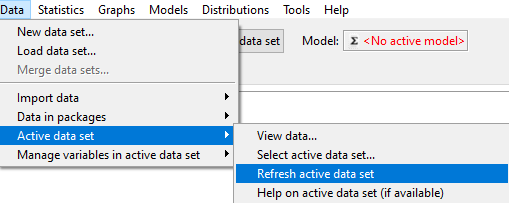

**This is only for R commander, R code does not require to refresh active data set !!!**

## 3.3 Save and export data into csv format

**Using Rcmdr point-and-click:**

Data -> Active data set -> Export active data set

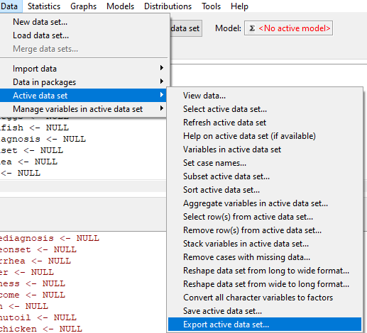

– Open the window and indicate several paramaters: - In the dialogue window that opens up, uncheck write wrote names - Type in missing value: NA - Select field separator commas[,] - In the next dialogue window that opens up, type in the new file name “leptospirosis_clean.csv” - Click OK

[figure not shown]

**Using R code:**

```r
> ## export data into csv
> write.table(leptodbfinal, "output/leptospirosis_clean.csv", sep=",", col.names=TRUE, row.names=FALSE, na="NA")
```

## 3.4 Subset data for Cases only

**Using Rcmdr point-and-click:**

Data -> Active data set -> Refresh active data set -> Subset active data set

[figure not shown]

- Name your new data file as **leptocase**

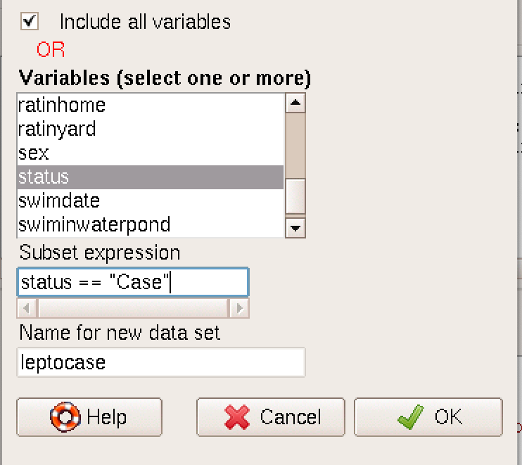

**Using R code:**

```r
> ## Select only confirmed cases.
> leptocase <- leptodbfinal %>% filter(status == "Case")
```

# 4 Leptospirosis data analysis.

## 4.1 N of cases

- Calculate N of cases of leptospirosis.
- Create new variable `nlpcs` count N of cases by counting `id` using formula:
- `nlpcs <- NROW(id)`

Here we use `NROW` with UPPERCASE which works with vectors different from `nrow`.

**Using Rcmdr point-and-click:**

Data -> Manage variables in active data set -> Compute new variable

- In the window **Expression to compute** write code **NROW(id)**

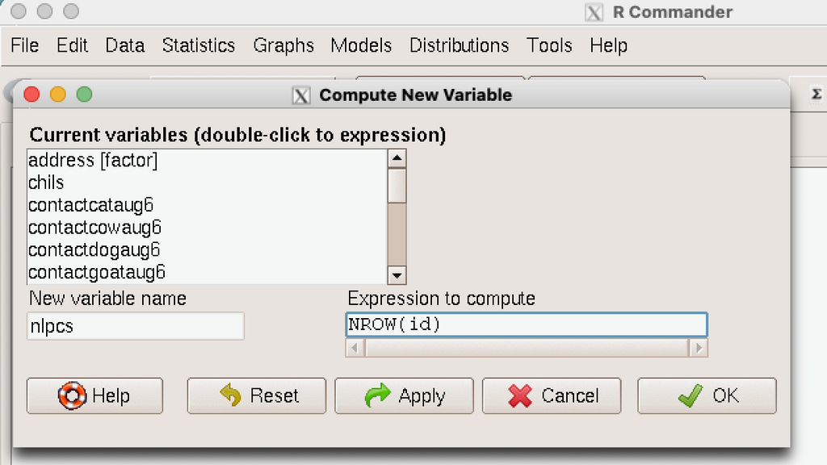

**Using R code:**

```r
> ## calcualte N of cases
> nlpcs <- NROW(leptocase$id)
```

## 4.2 Univariate data analysis

### 4.2.1 Continious data analysis of numeric variables

- Do summaries of the numeric variables for age, new_datediff
- Using Rcmdr point-and-click:

Statistics -> Summaries -> Numerical summaries

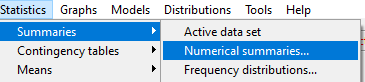

- In the dialogue window that opens up, select all variables you want to summarize.

[figure not shown]

- Click on the statistics tab and ensure that Mean, Standard Deviation, and Quantiles are checked.

[figure not shown]

- Calculate summary statistics of numeric variables “age”, “new_datediff” in RStudio.

```r
> numSummary(leptodbfinal[,c("age", "new_datediff"), drop=FALSE], statistics=c("mean", "sd", "quantiles"), quantiles=c(0,.25,.5,.75,1))
```

```
                 mean        sd 0%  25% 50%   75% 100%   n  NA
age          32.73333 18.987338  3 18.0  28 47.75   84 150   0
new_datediff 10.66667  3.137858  6  8.5  10 12.50   18  27 123
```